# 多因子模板之因子初选

陶阿明

2017/02/23

## 一、缺失值处理NA

多因子选股和单因子选股的不同在于因子之间的组合，无论是打分排序还是回归，首先都要对因子的缺失值进行处理。虽然可以利用中位数或者平均值等方法填充缺失值，但是当缺失值的确实比例达到一定程度，人为的填充缺失值，会破坏原有的因子分布特征，影响因子的有效性。

因而在进行后续研究之前，需要剔除缺失比例较高的因子。值得注意的是，在不同的样本空间内，因子的缺失比例也不同，举个最简单的例子，银行股预期因子基本没有缺失，但综合类行业的股票预期因子缺失比例较高。在**沪深300**样本空间内，因子缺失比例如下表所示。

|  | Min. | X1st.Qu. | Median | Mean | X3rd.Qu. | Max. |
| --- | --- | --- | --- | --- | --- | --- |
| F_NP_chg_w13 | 0.09 | 0.16 | 0.31 | 0.33 | 0.44 | 1.00 |
| F_ROE_1 | 0.09 | 0.16 | 0.31 | 0.32 | 0.43 | 1.00 |
| F_PE_1_ | 0.09 | 0.16 | 0.31 | 0.32 | 0.43 | 1.00 |
| F_target_rtn_1_2 | 0.11 | 0.17 | 0.21 | 0.24 | 0.26 | 1.00 |
| GG_NP_Q | 0.03 | 0.05 | 0.09 | 0.10 | 0.17 | 0.24 |
| F_rank_chg_60_1_2 | 0.01 | 0.03 | 0.05 | 0.09 | 0.08 | 1.00 |
| GG_OR_Q | 0.01 | 0.03 | 0.06 | 0.06 | 0.09 | 0.16 |
| NP_YOY | 0.01 | 0.02 | 0.03 | 0.05 | 0.06 | 0.18 |
| beta_ | 0.00 | 0.00 | 0.01 | 0.02 | 0.03 | 0.08 |
| ILLIQ | 0.00 | 0.01 | 0.01 | 0.01 | 0.02 | 0.06 |
| IVR_ | 0.00 | 0.01 | 0.01 | 0.01 | 0.02 | 0.06 |
| disposition_ | 0.00 | 0.00 | 0.00 | 0.01 | 0.01 | 0.03 |
| liquidity_ | 0.00 | 0.01 | 0.01 | 0.01 | 0.02 | 0.06 |
| G_MLL_Q | 0.00 | 0.00 | 0.00 | 0.00 | 0.00 | 0.00 |
| ln_mkt_cap_ | 0.00 | 0.00 | 0.00 | 0.00 | 0.00 | 0.00 |
| volatility_ | 0.00 | 0.00 | 0.00 | 0.00 | 0.00 | 0.00 |
| G_SCF_Q | 0.00 | 0.00 | 0.00 | 0.00 | 0.00 | 0.00 |
| pct_chg_per_60_ | 0.00 | 0.00 | 0.00 | 0.00 | 0.00 | 0.00 |
| PE_ttm_ | 0.00 | 0.00 | 0.00 | 0.00 | 0.00 | 0.00 |
| PB_mrq_ | 0.00 | 0.00 | 0.00 | 0.00 | 0.00 | 0.00 |

## 二、相关性展示Cor

在处理完因子的缺失值之后，我们开始处理因子的相关性。无论是打分排序还是回归，因子的相关性都是一个无法回避的问题。针对相关性较高的因子，要么将其组合成一个综合因子，要么剔除，如果因子都有效的话，组合为一个综合因子不失为一个较好的方法，如果因子效果不明显，不妨直接剔除。

衡量因子的相关性的有多种方法，这里采用的是最简单的每期因子标准化之后的相关性，然后做历史平均。历史上各因子值之间相关性如下图。

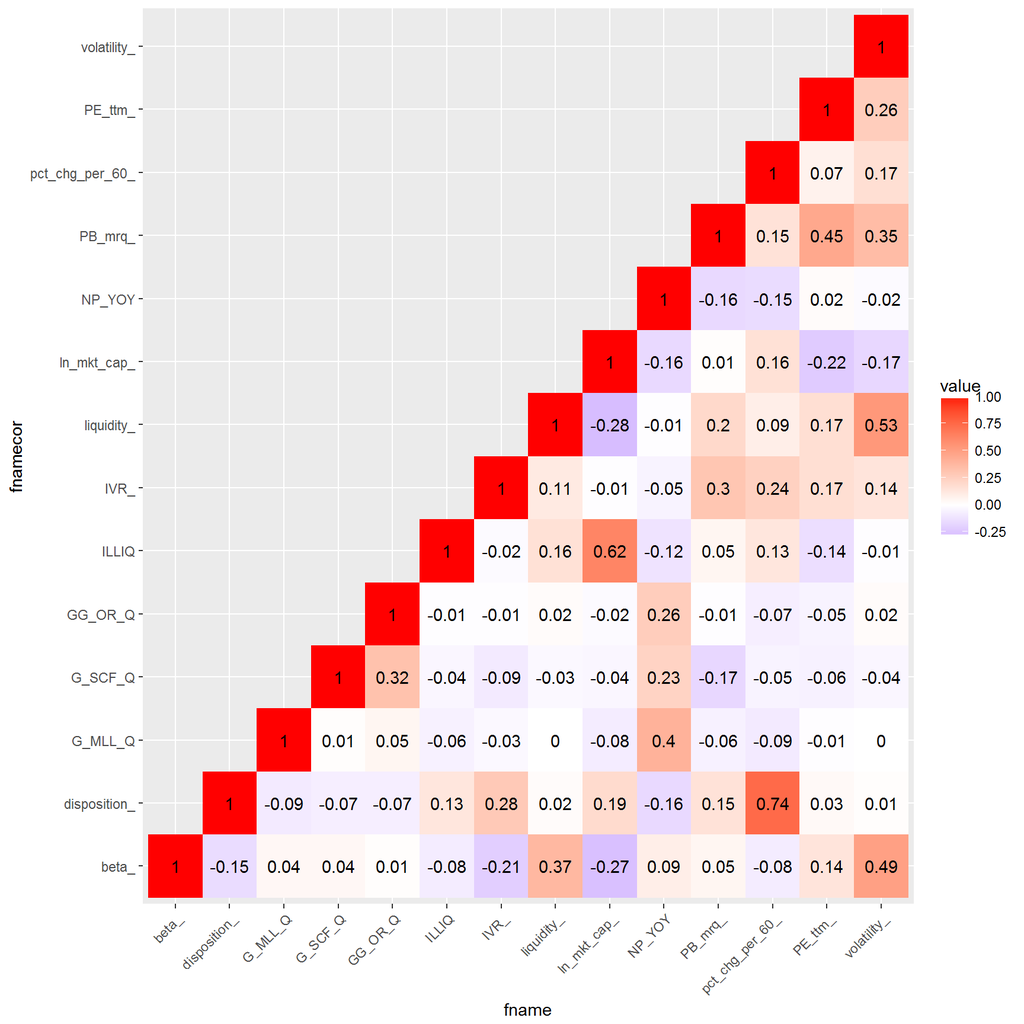

## 三、因子IC及分组

在处理完因子缺失值和因子相关性之后，开始进行因子的有效性检验。这一部分采用的是常用的IC和分组法。

### 各因子IC及分组

各因子的IC序列如下图所示。

```
## Function getTSR: getting the periodrtn ....
```

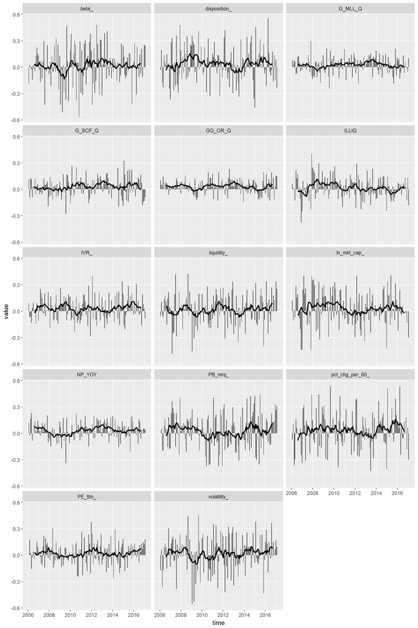

因子IC的统计如下表所示。

|  | IC_mean | IC_std | IC_IR | IC_t | IC_p | IC_hitRatio | IC_annu |
| --- | --- | --- | --- | --- | --- | --- | --- |
| disposition_ | 0.04 | 0.20 | 0.19 | 2.19 | 0.03 | 0.58 | 0.13 |
| GG_OR_Q | 0.03 | 0.08 | 0.43 | 4.95 | 0.00 | 0.72 | 0.12 |
| IVR_ | 0.03 | 0.13 | 0.26 | 2.96 | 0.00 | 0.61 | 0.12 |
| NP_YOY | 0.03 | 0.10 | 0.32 | 3.74 | 0.00 | 0.62 | 0.11 |
| ln_mkt_cap_ | 0.03 | 0.19 | 0.16 | 1.80 | 0.07 | 0.56 | 0.11 |
| PB_mrq_ | 0.03 | 0.20 | 0.15 | 1.69 | 0.09 | 0.56 | 0.10 |
| pct_chg_per_60_ | 0.03 | 0.20 | 0.14 | 1.63 | 0.11 | 0.57 | 0.10 |
| G_SCF_Q | 0.03 | 0.11 | 0.26 | 2.98 | 0.00 | 0.64 | 0.10 |
| G_MLL_Q | 0.03 | 0.09 | 0.28 | 3.21 | 0.00 | 0.68 | 0.09 |
| PE_ttm_ | 0.02 | 0.12 | 0.19 | 2.24 | 0.03 | 0.58 | 0.08 |
| liquidity_ | 0.02 | 0.18 | 0.12 | 1.36 | 0.18 | 0.57 | 0.07 |
| volatility_ | 0.02 | 0.20 | 0.10 | 1.13 | 0.26 | 0.57 | 0.07 |
| beta_ | 0.02 | 0.21 | 0.08 | 0.91 | 0.36 | 0.55 | 0.06 |
| ILLIQ | 0.02 | 0.13 | 0.13 | 1.48 | 0.14 | 0.56 | 0.06 |

各因子的分组年化收益如下图所示。

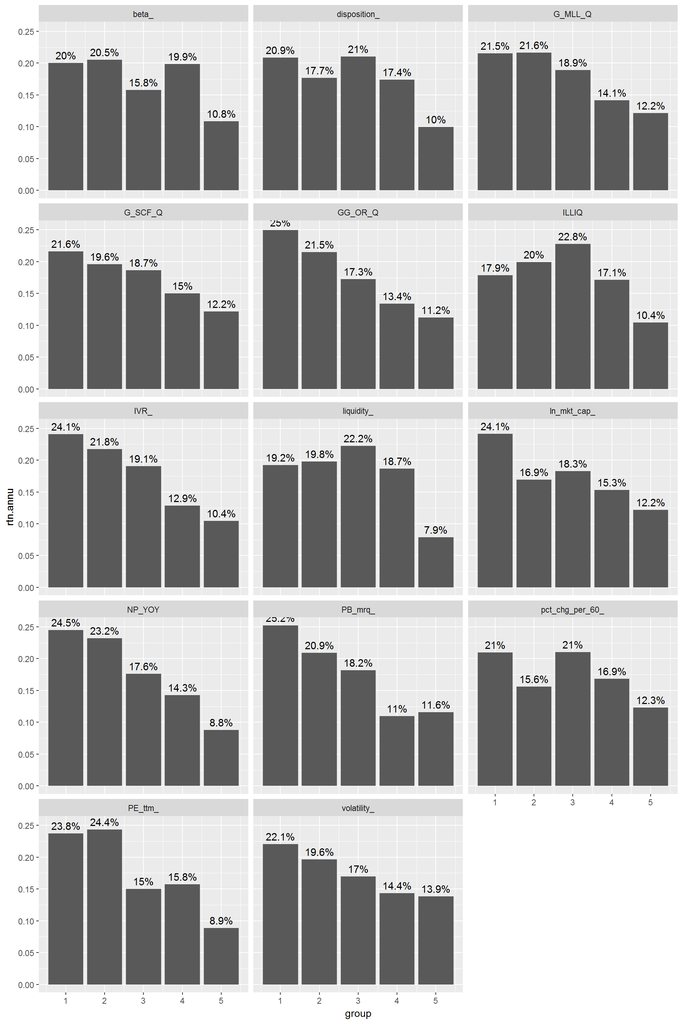

全部因子分组的统计如下表所示。

|  | Annualized.Return | Annualized.StdDev | Annualized.Sharpe.Rf.0.. | HitRatio | Worst.Drawdown | Annualized.Turnover | Annualized.Return..fee.cut. |
| --- | --- | --- | --- | --- | --- | --- | --- |
| NP_YOY | 0.13 | 0.12 | 1.06 | 0.67 | 0.31 | 2.56 | 0.13 |
| IVR_ | 0.13 | 0.14 | 0.93 | 0.62 | 0.19 | 7.48 | 0.13 |
| PE_ttm_ | 0.12 | 0.18 | 0.68 | 0.54 | 0.25 | 1.54 | 0.12 |
| GG_OR_Q | 0.11 | 0.09 | 1.29 | 0.65 | 0.19 | 2.30 | 0.11 |
| PB_mrq_ | 0.11 | 0.23 | 0.46 | 0.56 | 0.35 | 1.32 | 0.11 |
| ln_mkt_cap_ | 0.10 | 0.22 | 0.44 | 0.56 | 0.36 | 1.03 | 0.10 |
| disposition_ | 0.08 | 0.23 | 0.34 | 0.58 | 0.39 | 6.85 | 0.08 |
| G_MLL_Q | 0.08 | 0.10 | 0.78 | 0.64 | 0.20 | 2.30 | 0.08 |
| G_SCF_Q | 0.07 | 0.13 | 0.52 | 0.61 | 0.27 | 2.37 | 0.07 |
| ILLIQ | 0.05 | 0.15 | 0.36 | 0.59 | 0.28 | 3.03 | 0.05 |
| pct_chg_per_60_ | 0.05 | 0.23 | 0.21 | 0.59 | 0.37 | 5.63 | 0.05 |
| liquidity_ | 0.04 | 0.20 | 0.19 | 0.56 | 0.41 | 3.48 | 0.04 |
| volatility_ | 0.01 | 0.21 | 0.04 | 0.55 | 0.54 | 3.02 | 0.01 |
| beta_ | 0.01 | 0.22 | 0.03 | 0.56 | 0.53 | 1.35 | 0.01 |

### alpha因子IC及分组及相关性

综合IC的绝对值、波动率、胜率以及因子分组的表现，选出长期来看有alpha性的因子。alpha因子IC序列如下图所示。

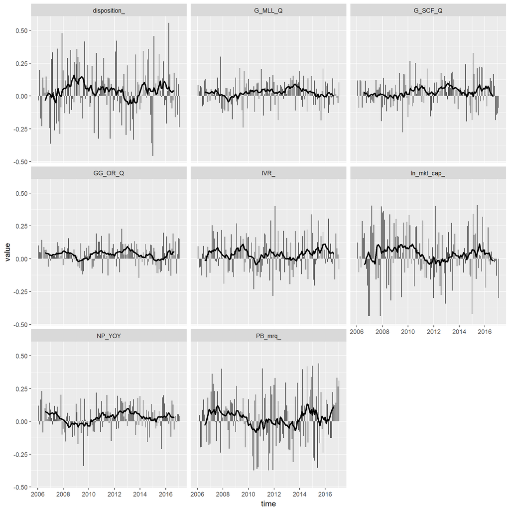

alpha因子分组收益如下图所示。

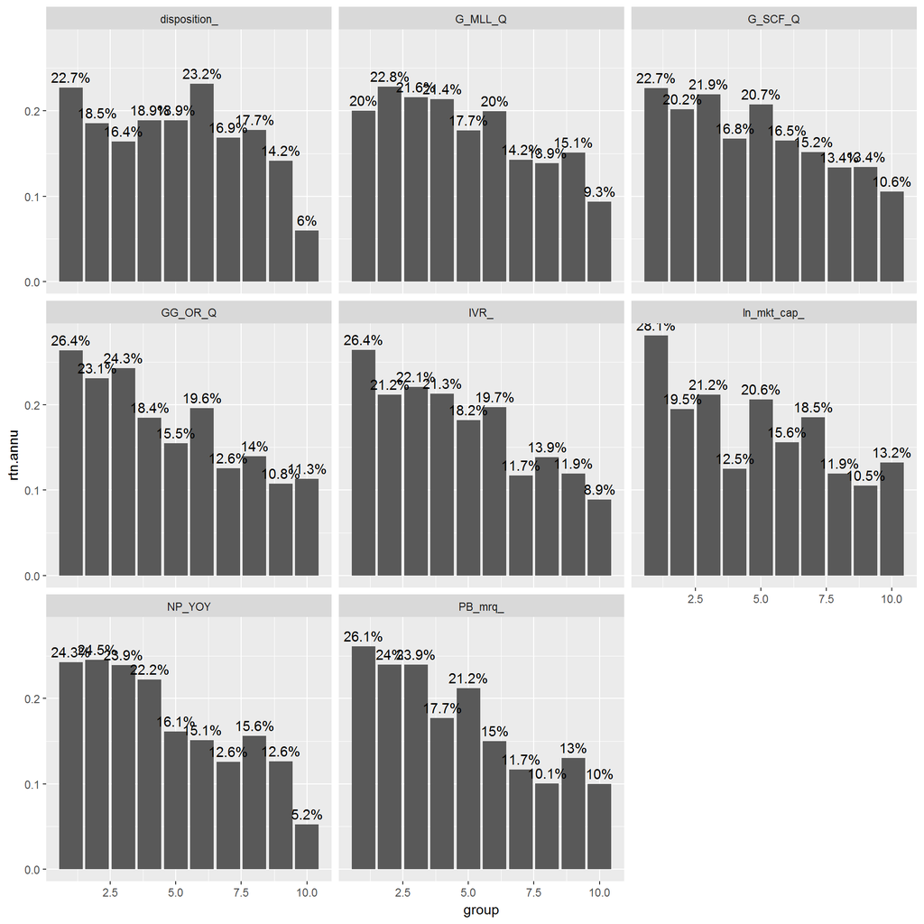

根据前面的分析，alpha因子每期相关性如下图。

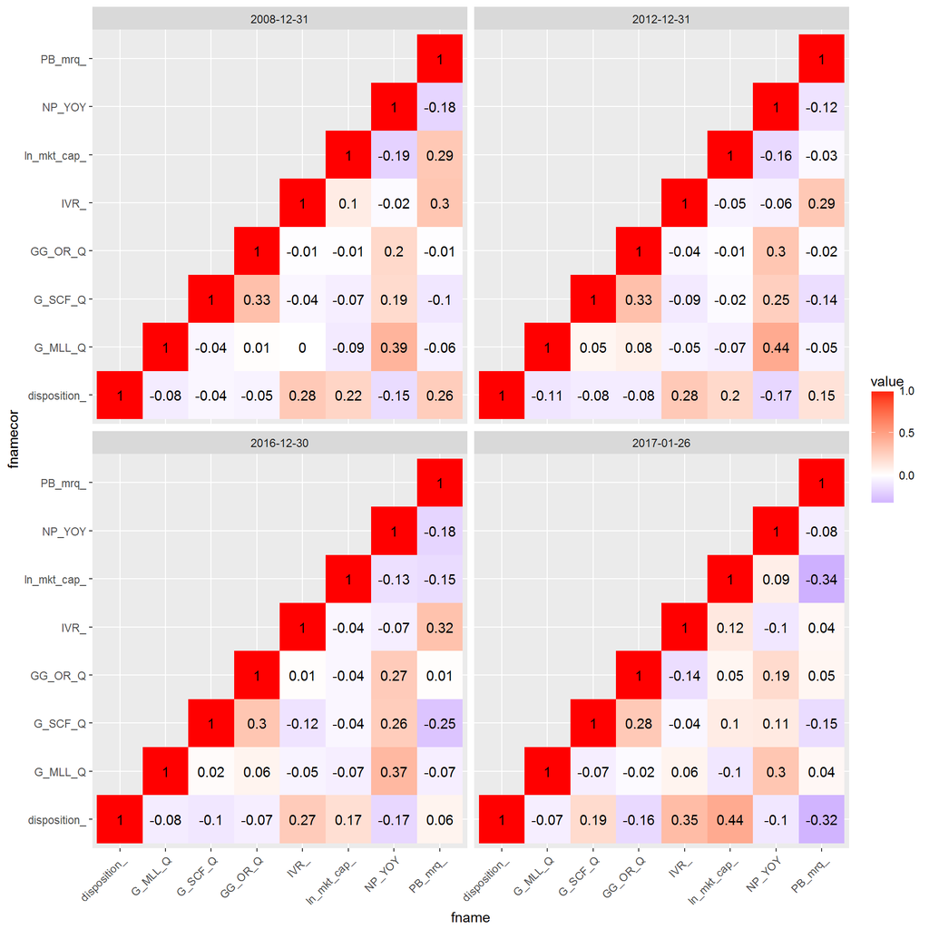

alpha因子IC相关性如下图所示。

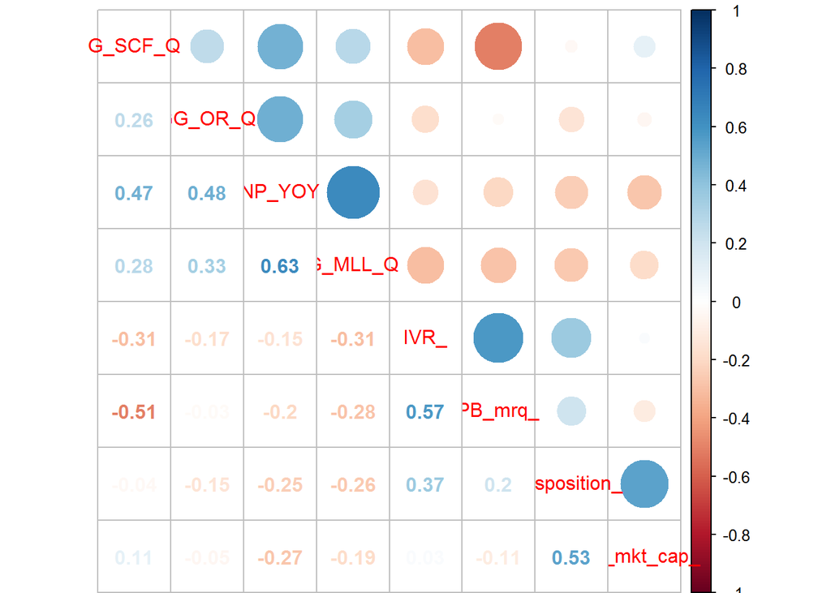

### 综合因子IC及分组

将上述的alpha因子综合为一个新的综合因子，综合因子的IC序列如下图。

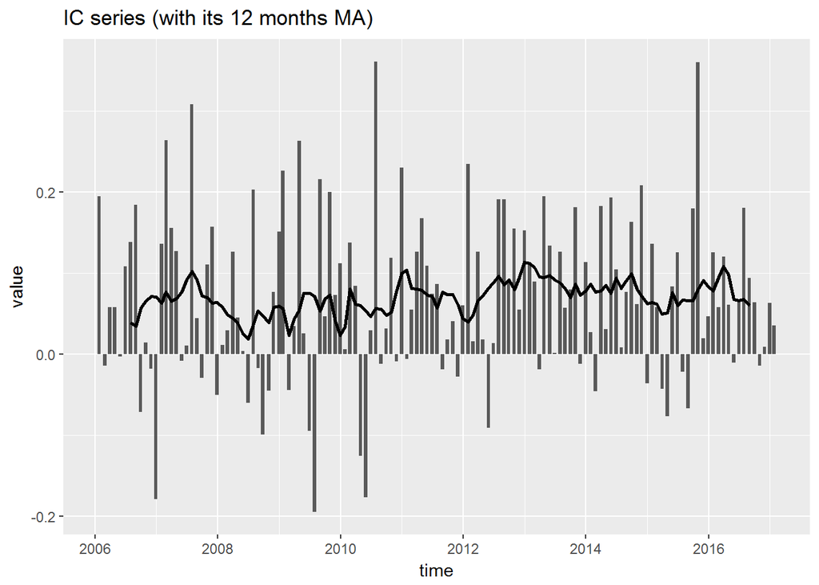

综合因子的IC统计如下。

|  | IC |
| --- | --- |
| IC_mean | 0.07 |
| IC_std | 0.10 |
| IC_IR | 0.68 |
| IC_t | 7.87 |
| IC_p | 0.00 |
| IC_hitRatio | 0.75 |
| IC_annu | 0.24 |

综合因子的分组表现如下图。

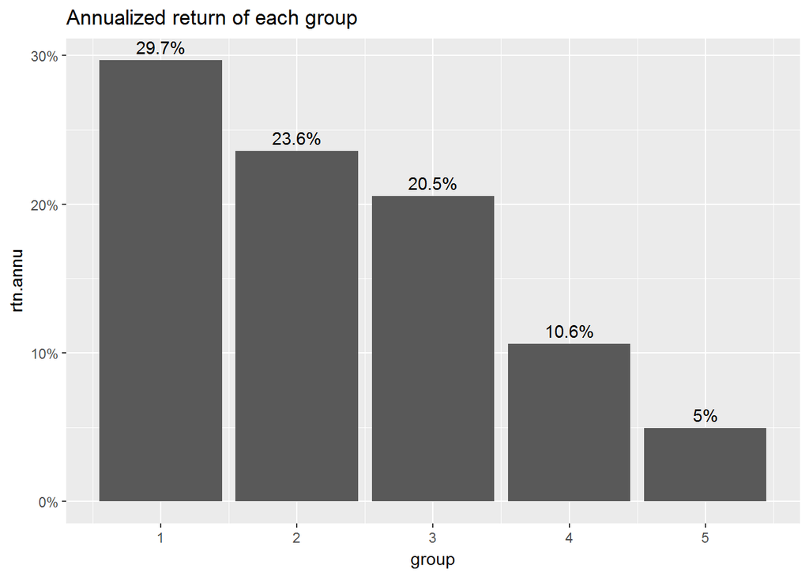

综合因子的历年分组表现如下图。

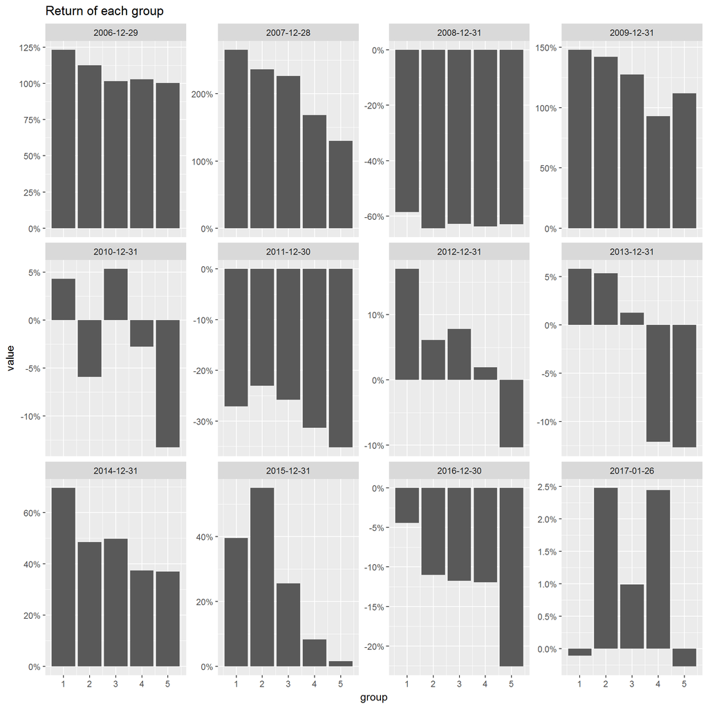

综合因子的多空收益如下图。

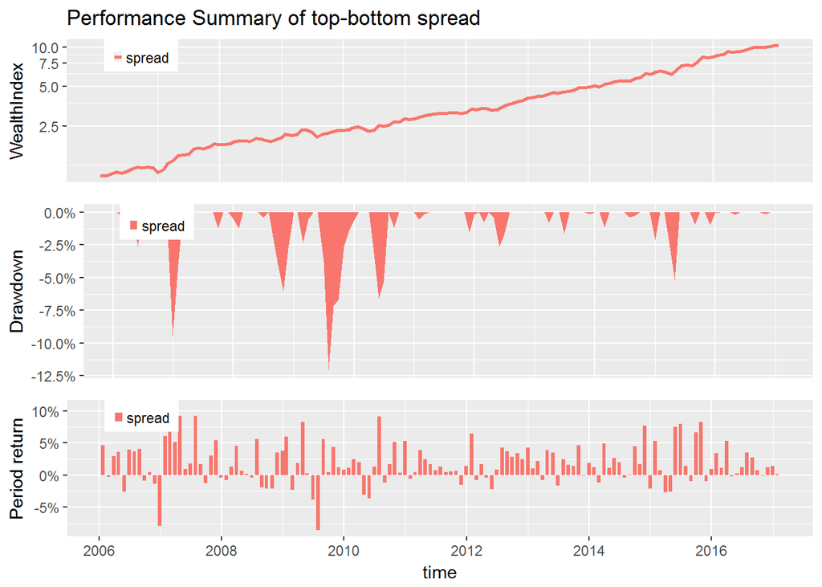

## 四、基于回归的因子分析法Reg

上述因子IC、因子分组是一种检验因子有效性的方法。下面介绍的基于回归的因子分析方法是近期比较热门的一种方法，基于回归的方法可以更好地剥离因子之间的相关性，可以集中暴露某些因子，是一种**看上去**更为科学的分析方法。模型本身各有优劣，关键在于使用模型的人。

回归法筛选因子比较简单，就是根据每期因子对回归的$R^2$的贡献度，结合因子的收益率稳定性来筛选。具体的细节可以参考东方证券的几篇研究报告，这里不一一展开。

回归法的因子筛选结果如下表所示。

| fname | rsquare | frtn | fttest | pttest | tag |
| --- | --- | --- | --- | --- | --- |
| sector | 0.5291 | NA | NA | NA | risk |
| ln_mkt_cap_ | 0.5463 | 0.0032 | 1.8581 | 0.0654 | risk |
| pct_chg_per_60_ | 0.5575 | 0.0044 | 3.1082 | 0.0023 | alpha |
| volatility_ | 0.5672 | 0.0031 | 1.8134 | 0.0720 | risk |
| PB_mrq_ | 0.5751 | 0.0030 | 2.4157 | 0.0171 | alpha |
| disposition_ | 0.5808 | 0.0047 | 2.9260 | 0.0040 | alpha |
| liquidity_ | 0.5861 | 0.0033 | 3.0550 | 0.0027 | alpha |
| beta_ | 0.5908 | 0.0023 | 1.4487 | 0.1498 | risk |
| NP_YOY | 0.5941 | 0.0041 | 6.5723 | 0.0000 | alpha |
| IVR_ | 0.5971 | 0.0016 | 1.9159 | 0.0575 | risk |
| PE_ttm_ | 0.6001 | 0.0013 | 1.9673 | 0.0512 | risk |
| G_SCF_Q | 0.6027 | 0.0022 | 3.4499 | 0.0008 | alpha |
| ILLIQ | 0.6049 | -0.0008 | -0.9091 | 0.3650 | risk |
| GG_OR_Q | 0.6068 | 0.0009 | 1.3917 | 0.1663 | risk |
| G_MLL_Q | 0.6086 | 0.0009 | 1.7886 | 0.0760 | risk |

在展示纯因子组合收益之前，先展示一下每期回归的$R^2$，如下图所示。

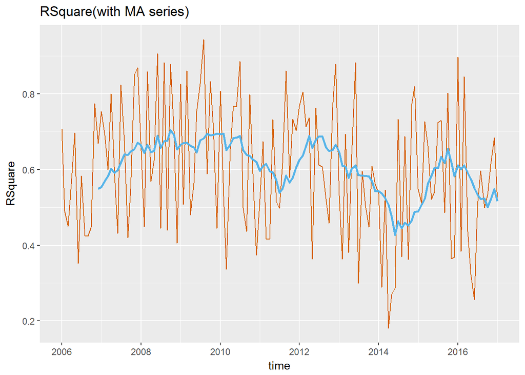

各因子的纯因子组合累积净值曲线如下图所示。

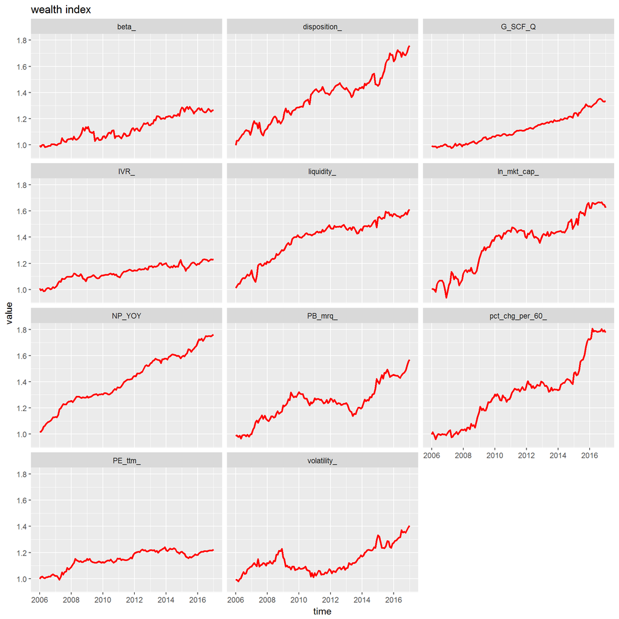

纯因子组合收益率如下图所示。

| fname | Annual Return | Annual StdDev | Sharpe | HitRatio | Worst Drawdown | mean(abs(T)) | percent T>2 | vif |
| --- | --- | --- | --- | --- | --- | --- | --- | --- |
| NP_YOY | 0.05 | 0.03 | 2.03 | 0.72 | 0.02 | 1.12 | 0.17 | 1 |
| G_SCF_Q | 0.03 | 0.03 | 1.04 | 0.66 | 0.03 | 1.06 | 0.11 | 1 |
| liquidity_ | 0.04 | 0.05 | 0.92 | 0.61 | 0.08 | 1.49 | 0.20 | 1 |
| pct_chg_per_60_ | 0.05 | 0.06 | 0.89 | 0.57 | 0.06 | 2.30 | 0.29 | 1 |
| disposition_ | 0.05 | 0.06 | 0.86 | 0.64 | 0.09 | 1.57 | 0.21 | 1 |
| PB_mrq_ | 0.04 | 0.05 | 0.76 | 0.57 | 0.14 | 2.02 | 0.29 | 1 |
| ln_mkt_cap_ | 0.04 | 0.07 | 0.63 | 0.56 | 0.12 | 2.87 | 0.35 | 1 |
| PE_ttm_ | 0.02 | 0.03 | 0.58 | 0.59 | 0.07 | 1.12 | 0.09 | 1 |
| IVR_ | 0.02 | 0.03 | 0.58 | 0.59 | 0.07 | 1.15 | 0.11 | 1 |
| volatility_ | 0.03 | 0.06 | 0.50 | 0.59 | 0.18 | 2.12 | 0.32 | 1 |
| beta_ | 0.02 | 0.05 | 0.42 | 0.58 | 0.09 | 1.48 | 0.17 | 1 |

各因子的纯因子组合收益柱状图如下图所示。

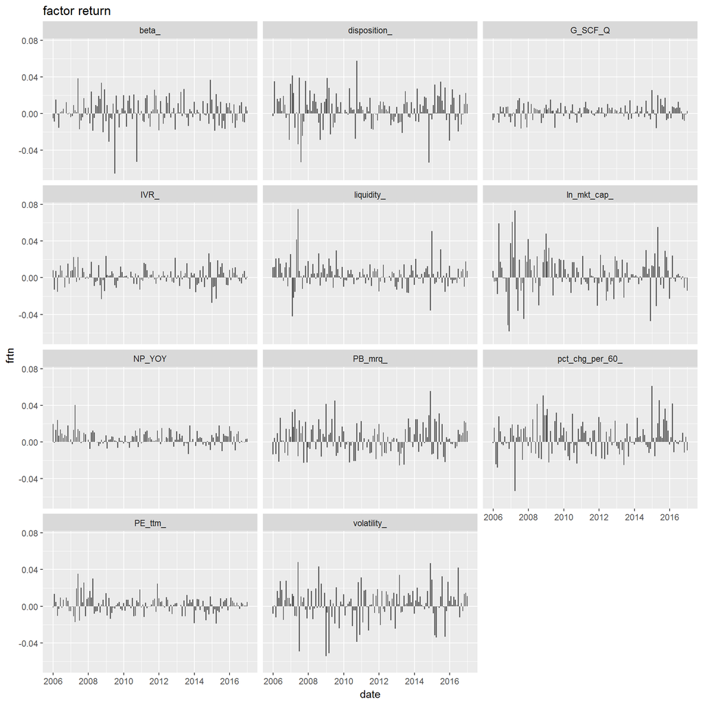

各因子的纯因子组合收益率相关性如下图所示。

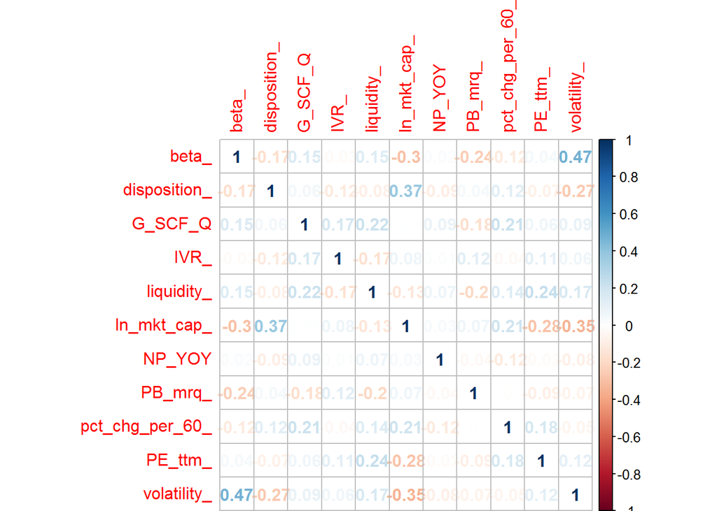